# Hypothesis Tests

### UberXL vs Lyft XL

```r
current <- c("UberXL", "Lyft XL")

d3 <- data_ppm[data_ppm$name %in% current,]
```

Distributions:

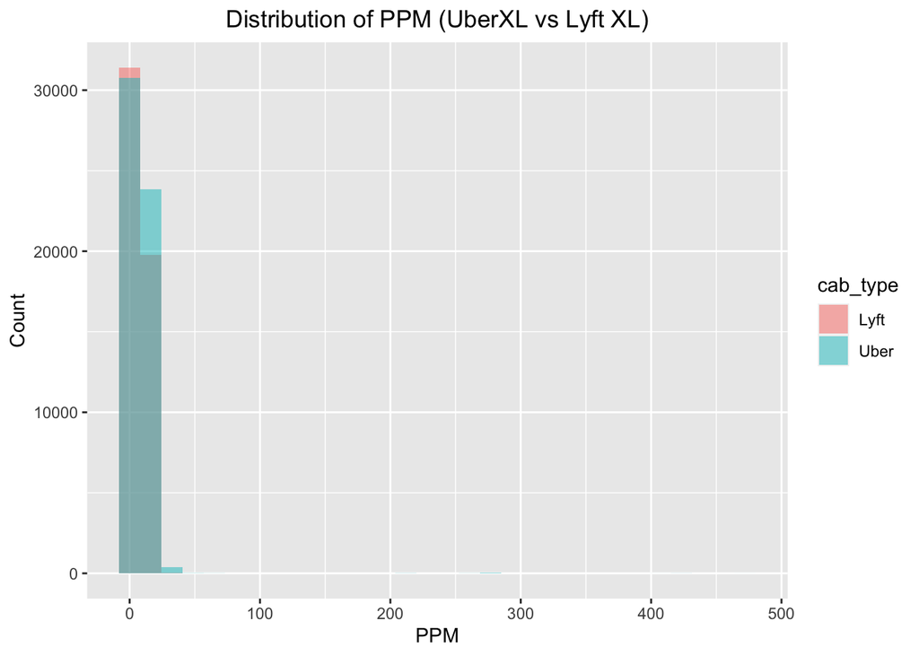

```r
ggplot(d3, aes(x=ppm, fill=cab_type)) +
  geom_histogram(position = "identity", alpha = 0.5) +
  ggtitle('Distribution of PPM (UberXL vs Lyft XL)') +
  theme(plot.title = element_text(hjust = 0.5)) +
  ylab('Count') +
  xlab('PPM')
```

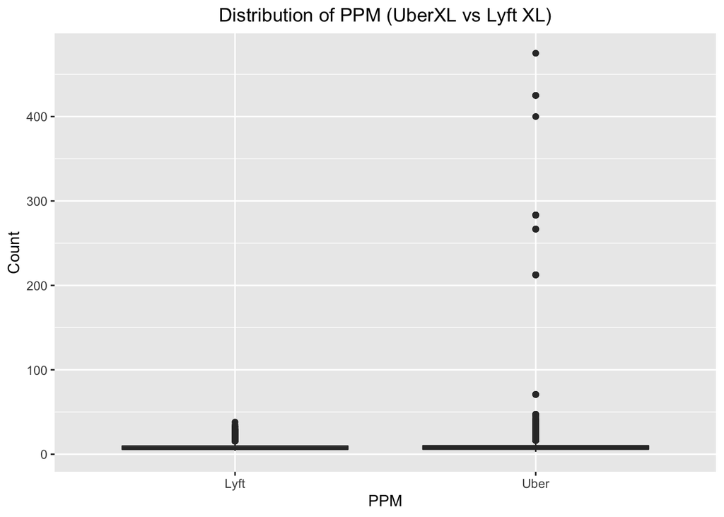

```r
ggplot(d3, aes(cab_type, ppm)) +
  geom_boxplot() +
  ggtitle('Distribution of PPM (UberXL vs Lyft XL)') +
  theme(plot.title = element_text(hjust = 0.5)) +
  ylab('Count') +
  xlab('PPM')
```

As above, Uber has some pretty high PPM values.

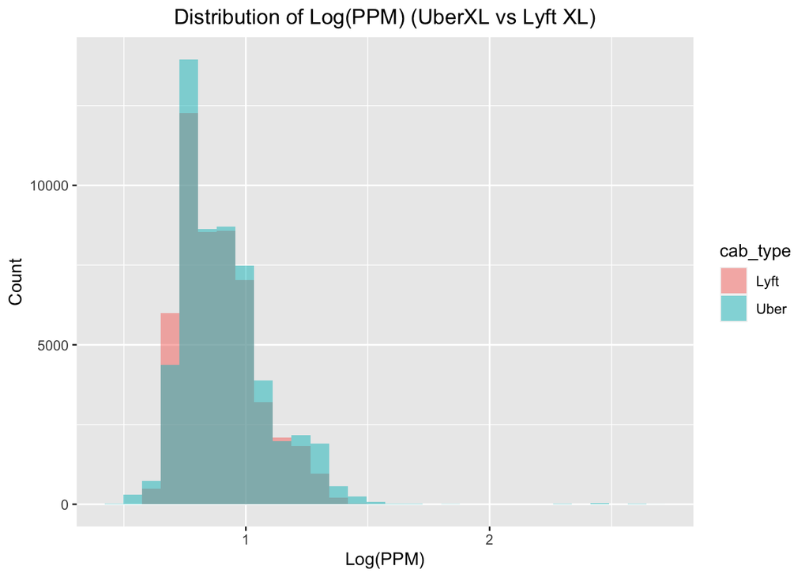

```r
ggplot(d3, aes(x=log10(ppm), fill=cab_type)) +
  geom_histogram(position = "identity", alpha = 0.5) +
  ggtitle('Distribution of Log(PPM) (UberXL vs Lyft XL)') +
  theme(plot.title = element_text(hjust = 0.5)) +
  ylab('Count') +
  xlab('Log(PPM)')
```

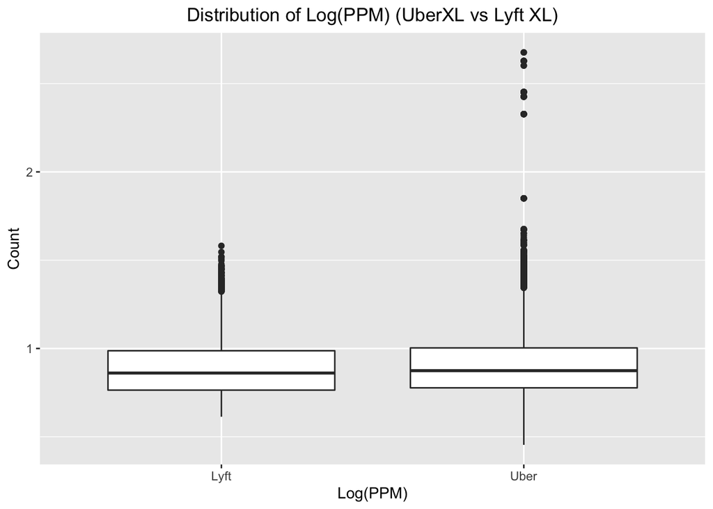

```r
ggplot(d3, aes(cab_type, log10(ppm))) +
  geom_boxplot() +
  ggtitle('Distribution of Log(PPM) (UberXL vs Lyft XL)') +
  theme(plot.title = element_text(hjust = 0.5)) +
  ylab('Count') +
  xlab('Log(PPM)')
```

We’ll run the same tests as above.

```r
mu_ppm_u3 <- mean(d3$ppm[d3$cab_type == "Uber"], na.rm=TRUE)
mu_ppm_l3 <- mean(d3$ppm[d3$cab_type == "Lyft"], na.rm=TRUE)
```

Mean PPM (UberXL):

```r
mu_ppm_u3
```

```
## [1] 9.131168
```

Mean PPM (Lyft XL):

```r
mu_ppm_l3
```

```
## [1] 8.303925
```

Difference in Mean PPM:

```r
mu_ppm_u3 - mu_ppm_l3
```

```
## [1] 0.8272426
```

Almost a whole dollar difference. Let’s look at the t-test and Mann-Whitney U test.

```r
t.test(ppm~cab_type, d3)
```

```
##
##  Welch Two Sample t-test
##
## data:  ppm by cab_type
## t = -17.484, df = 67648, p-value < 2.2e-16
## alternative hypothesis: true difference in means between group Lyft and group Uber is not equal to 0
## 95 percent confidence interval:
##  -0.9199759 -0.7345094
## sample estimates:
## mean in group Lyft mean in group Uber
##           8.303925           9.131168
```

```r
wilcox.test(ppm~cab_type, d3)
```

```
##
##  Wilcoxon rank sum test with continuity correction
##
## data:  ppm by cab_type
## W = 1336570446, p-value < 2.2e-16
## alternative hypothesis: true location shift is not equal to 0
```

```r
t.test(log10(ppm)~cab_type, d3)
```

```
##
##  Welch Two Sample t-test
##
## data:  log10(ppm) by cab_type
## t = -18.589, df = 105499, p-value < 2.2e-16
## alternative hypothesis: true difference in means between group Lyft and group Uber is not equal to 0
## 95 percent confidence interval:
##  -0.02116316 -0.01712606
## sample estimates:
## mean in group Lyft mean in group Uber
##          0.8893179          0.9084625
```

```r
wilcox.test(log10(ppm)~cab_type, d3)
```

```
##
##  Wilcoxon rank sum test with continuity correction
##
## data:  log10(ppm) by cab_type
## W = 1336563680, p-value < 2.2e-16
## alternative hypothesis: true location shift is not equal to 0
```

There is a significant difference between UberXL and Lyft XL because both tests result in p-values < 0.05. This is true for both the original or log-transformed data. For a third time, Lyft is cheaper.

### Uber Black vs Lyft Lux Black

```r
current <- c("Black", "Lux Black")

d4 <- data_ppm[data_ppm$name %in% current,]
```

Distributions:

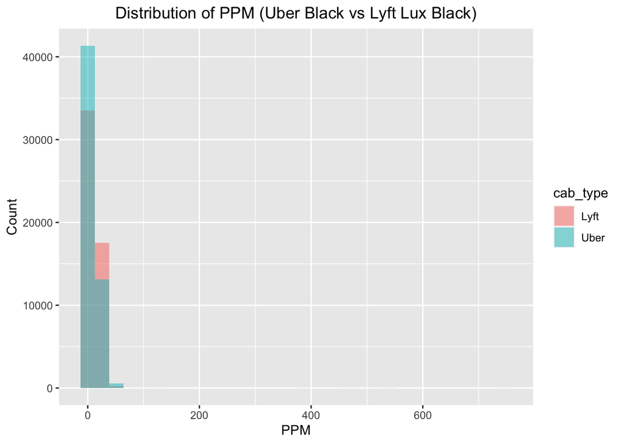

```r
ggplot(d4, aes(x=ppm, fill=cab_type)) +
  geom_histogram(position = "identity", alpha = 0.5) +
  ggtitle('Distribution of PPM (Uber Black vs Lyft Lux Black)') +
  theme(plot.title = element_text(hjust = 0.5)) +
  ylab('Count') +
  xlab('PPM')
```

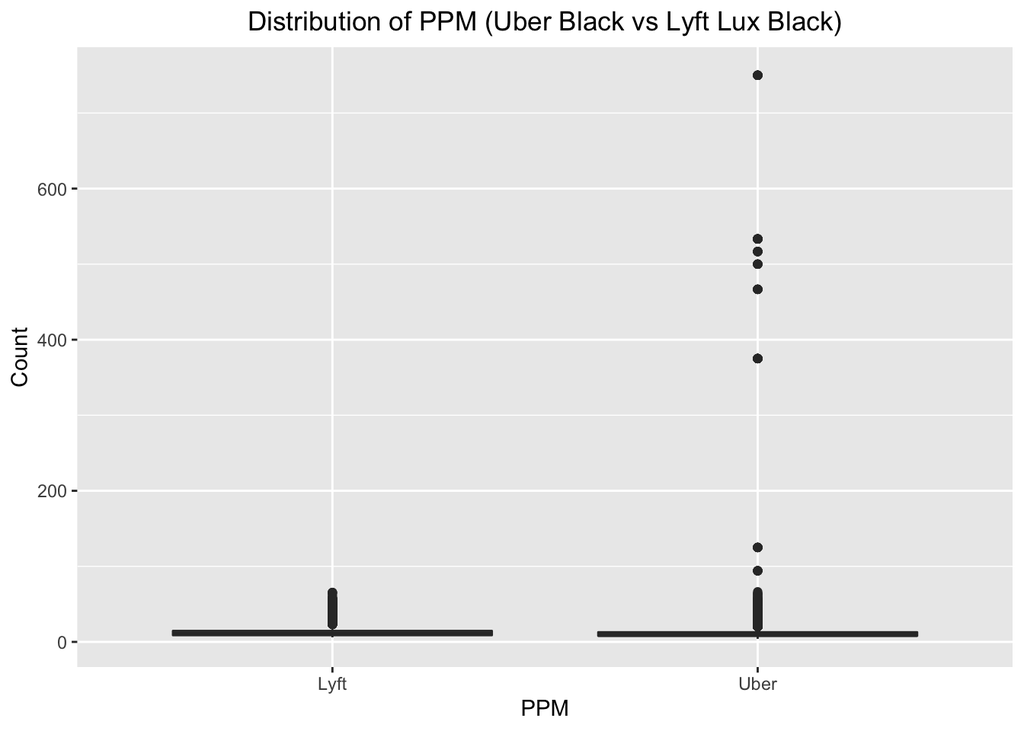

```r
ggplot(d4, aes(cab_type, ppm)) +
  geom_boxplot() +
  ggtitle('Distribution of PPM (Uber Black vs Lyft Lux Black)') +
  theme(plot.title = element_text(hjust = 0.5)) +
  ylab('Count') +
  xlab('PPM')
```

We’re seeing the same issue with the large values of Uber as we have previously.

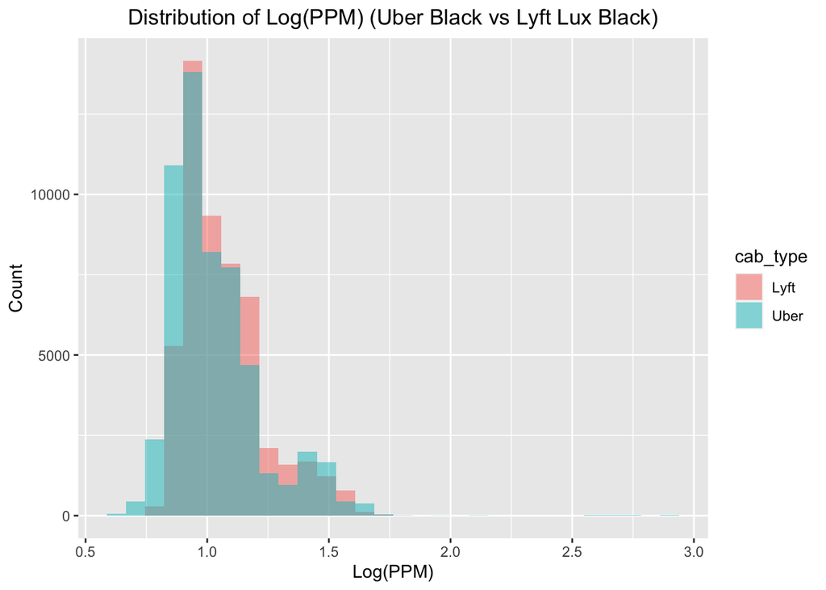

```r
ggplot(d4, aes(x=log10(ppm), fill=cab_type)) +
  geom_histogram(position = "identity", alpha = 0.5) +
  ggtitle('Distribution of Log(PPM) (Uber Black vs Lyft Lux Black)') +
  theme(plot.title = element_text(hjust = 0.5)) +
  ylab('Count') +
  xlab('Log(PPM)')
```

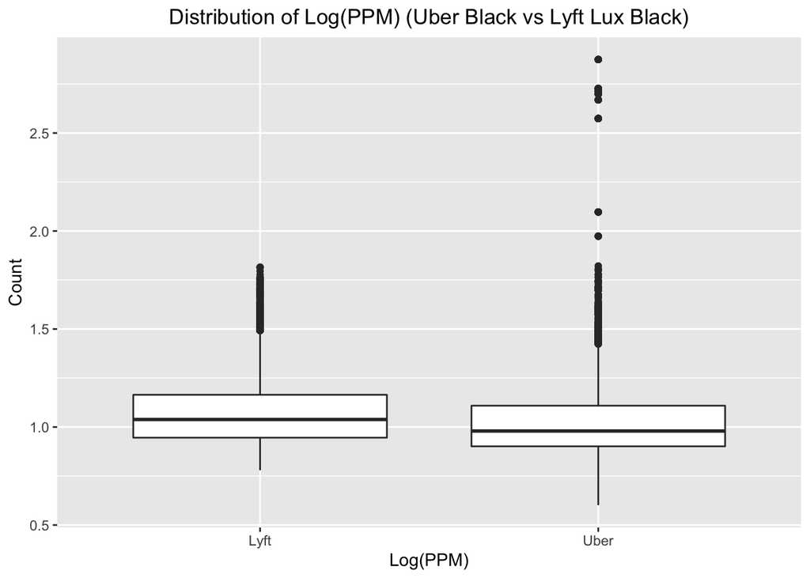

```r
ggplot(d4, aes(cab_type, log10(ppm))) +
  geom_boxplot() +
  ggtitle('Distribution of Log(PPM) (Uber Black vs Lyft Lux Black)') +
  theme(plot.title = element_text(hjust = 0.5)) +
  ylab('Count') +
  xlab('Log(PPM)')
```

```r
mu_ppm_u4 <- mean(d4$ppm[d4$cab_type == "Uber"], na.rm=TRUE)
mu_ppm_l4 <- mean(d4$ppm[d4$cab_type == "Lyft"], na.rm=TRUE)
```

Mean PPM (Uber Black):

```r
mu_ppm_u4
```

```
## [1] 12.3733
```

Mean PPM (Lyft Lux Black):

```r
mu_ppm_l4
```

```
## [1] 12.76405
```

Difference in Mean PPM:

```r
mu_ppm_l4 - mu_ppm_u4
```

```
## [1] 0.3907544
```

Let’s look at the significance.

```r
t.test(ppm~cab_type, d4)
```

```
##
##  Welch Two Sample t-test
##
## data:  ppm by cab_type
## t = 4.7605, df = 68454, p-value = 1.935e-06
## alternative hypothesis: true difference in means between group Lyft and group Uber is not equal to 0
## 95 percent confidence interval:
##  0.2298733 0.5516356
## sample estimates:
## mean in group Lyft mean in group Uber
##           12.76405           12.37330
```

```r
wilcox.test(ppm~cab_type, d4)
```

```
##
##  Wilcoxon rank sum test with continuity correction
##
## data:  ppm by cab_type
## W = 1674526828, p-value < 2.2e-16
## alternative hypothesis: true location shift is not equal to 0
```

```r
t.test(log10(ppm)~cab_type, d4)
```

```
##
##  Welch Two Sample t-test
##
## data:  log10(ppm) by cab_type
## t = 36.486, df = 105932, p-value < 2.2e-16
## alternative hypothesis: true difference in means between group Lyft and group Uber is not equal to 0
## 95 percent confidence interval:
##  0.03764163 0.04191533
## sample estimates:
## mean in group Lyft mean in group Uber
##           1.069692           1.029913
```

```r
wilcox.test(log10(ppm)~cab_type, d4)
```

```
##
##  Wilcoxon rank sum test with continuity correction
##
## data:  log10(ppm) by cab_type
## W = 1674500935, p-value < 2.2e-16
## alternative hypothesis: true location shift is not equal to 0
```

The difference is significant in both tests and on both the original and log-transformed data. For the first time, Uber is less expensive!

### Uber Black SUV vs Lyft Lux Black XL

```r
current <- c("Black SUV", "Lux Black XL")

d5 <- data_ppm[data_ppm$name %in% current,]
```

Distributions:

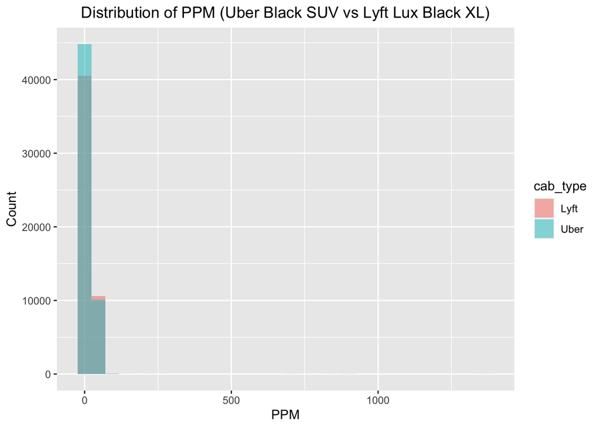

```r
ggplot(d5, aes(x=ppm, fill=cab_type)) +
  geom_histogram(position = "identity", alpha = 0.5) +
  ggtitle('Distribution of PPM (Uber Black SUV vs Lyft Lux Black XL)') +
  theme(plot.title = element_text(hjust = 0.5)) +
  ylab('Count') +
  xlab('PPM')
```

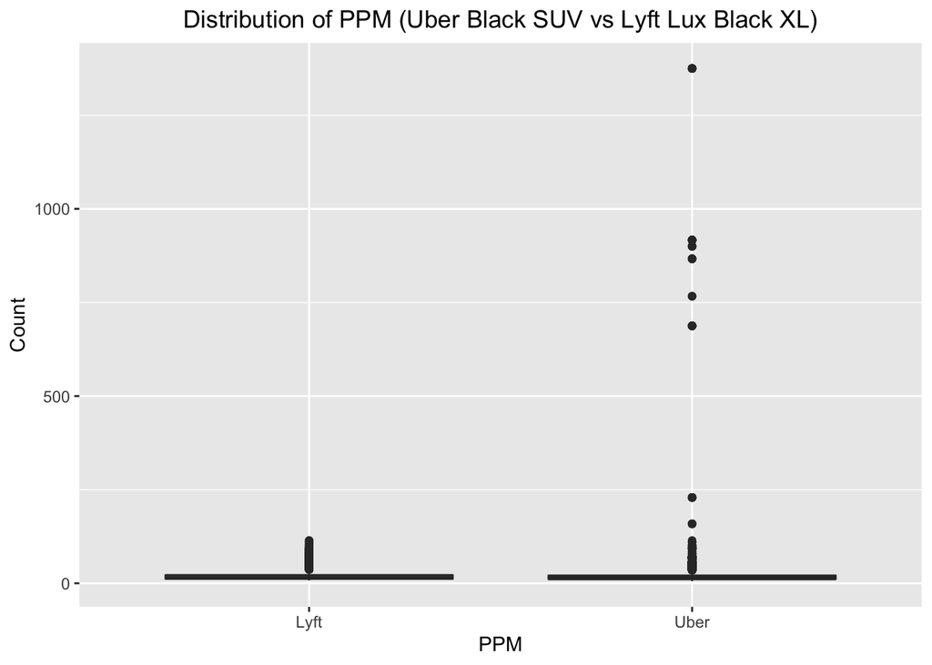

```r
ggplot(d5, aes(cab_type, ppm)) +
  geom_boxplot() +
  ggtitle('Distribution of PPM (Uber Black SUV vs Lyft Lux Black XL)') +
  theme(plot.title = element_text(hjust = 0.5)) +
  ylab('Count') +
  xlab('PPM')
```

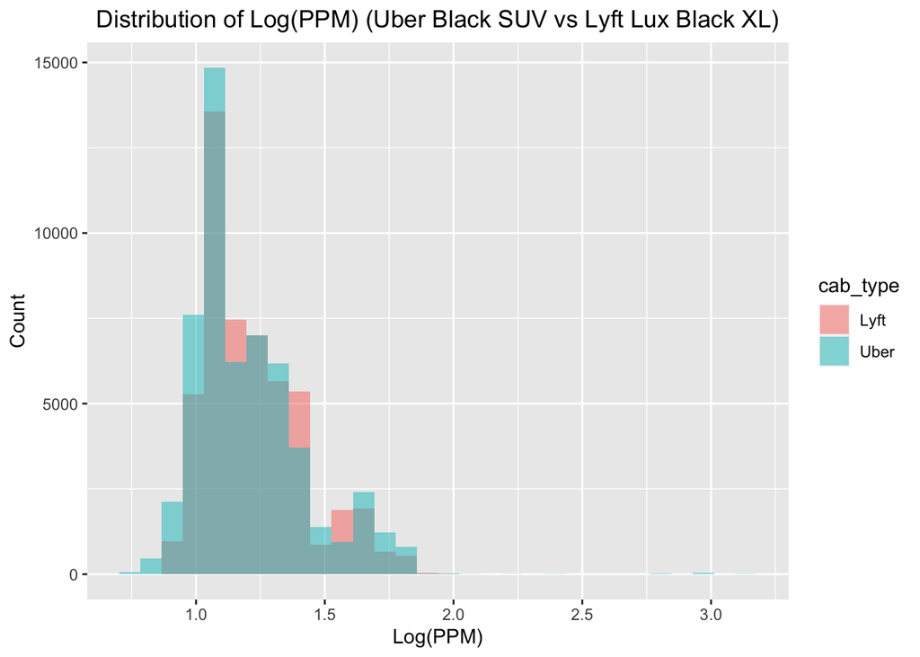

```r
ggplot(d5, aes(x=log10(ppm), fill=cab_type)) +
  geom_histogram(position = "identity", alpha = 0.5) +
  ggtitle('Distribution of Log(PPM) (Uber Black SUV vs Lyft Lux Black XL)') +
  theme(plot.title = element_text(hjust = 0.5)) +
  ylab('Count') +
  xlab('Log(PPM)')
```

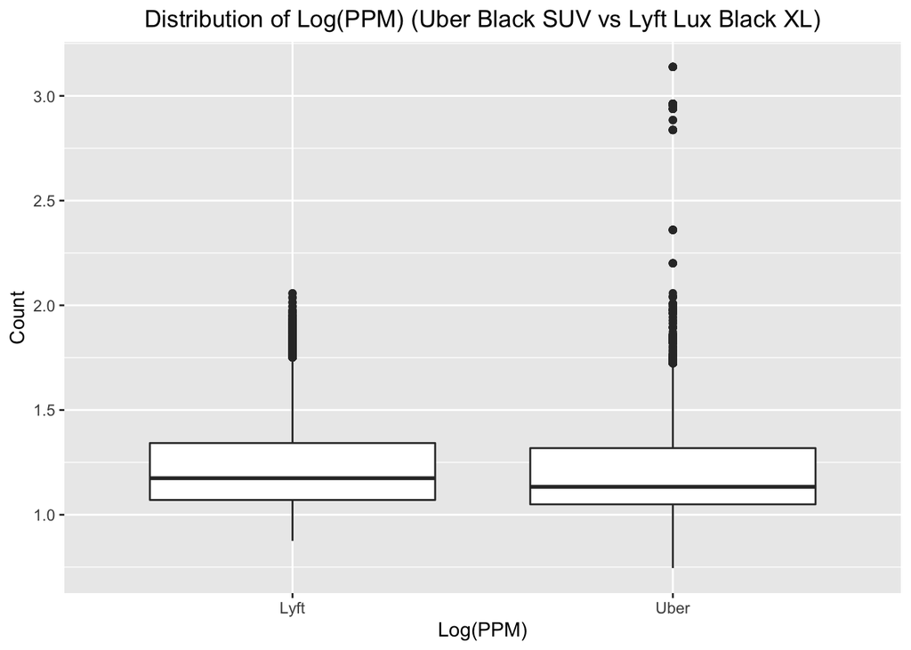

```r
ggplot(d5, aes(cab_type, log10(ppm))) +
  geom_boxplot() +
  ggtitle('Distribution of Log(PPM) (Uber Black SUV vs Lyft Lux Black XL)') +
  theme(plot.title = element_text(hjust = 0.5)) +
  ylab('Count') +
  xlab('Log(PPM)')
```

Same thing as before.

```r
mu_ppm_u5 <- mean(d5$ppm[d5$cab_type == "Uber"], na.rm=TRUE)
mu_ppm_l5 <- mean(d5$ppm[d5$cab_type == "Lyft"], na.rm=TRUE)
```

Mean PPM (Uber Black SUV):

```r
mu_ppm_u5
```

```
## [1] 19.42508
```

Mean PPM (Lyft Lux Black XL):

```r
mu_ppm_l5
```

```
## [1] 18.76586
```

Difference in Mean PPM:

```r
mu_ppm_l5 - mu_ppm_u5
```

```
## [1] -0.6592143
```

Again, Lyft is cheaper.

```r
t.test(ppm~cab_type, d5)
```

```
##
##  Welch Two Sample t-test
##
## data:  ppm by cab_type
## t = -4.4782, df = 67719, p-value = 7.539e-06
## alternative hypothesis: true difference in means between group Lyft and group Uber is not equal to 0
## 95 percent confidence interval:
##  -0.9477351 -0.3706934
## sample estimates:
## mean in group Lyft mean in group Uber
##           18.76586           19.42508
```

```r
wilcox.test(ppm~cab_type, d5)
```

```
##
##  Wilcoxon rank sum test with continuity correction
##
## data:  ppm by cab_type
## W = 1527481088, p-value < 2.2e-16
## alternative hypothesis: true location shift is not equal to 0
```

```r
t.test(log10(ppm)~cab_type, d5)
```

```
##
##  Welch Two Sample t-test
##
## data:  log10(ppm) by cab_type
## t = 13.262, df = 106067, p-value < 2.2e-16
## alternative hypothesis: true difference in means between group Lyft and group Uber is not equal to 0
## 95 percent confidence interval:
##  0.01450947 0.01954172
## sample estimates:
## mean in group Lyft mean in group Uber
##           1.222467           1.205441
```

```r
wilcox.test(log10(ppm)~cab_type, d5)
```

```
##
##  Wilcoxon rank sum test with continuity correction
##
## data:  log10(ppm) by cab_type
## W = 1527477122, p-value < 2.2e-16
## alternative hypothesis: true location shift is not equal to 0
```

There is a significant difference between the groups according to all 4 tests performed. Like above, Lyft is cheaper.

### Conclusion

Overall, both the mean price and the price per mile (PPM) of Uber is less than that of Lyft. However, when we break Uber and Lyft down to compare specific Uber and Lyft types, we see that Lyft is less expensive in PPM in every sub-category except for Uber Black vs Lyft Lux Black. For most rideshare needs, it is my advice that you call a Lyft.

Additionally, there is no significant difference between the mean cost during the day and during the night. There is also no difference between the mean cost during the week and during the weekend.

Finally, the surge multiplier variable is only present for Lyft and therefore only useful for predicting Lyft prices but not for comparing Lyft to Uber.

### Sources

Mann-Whitney U Test: https://www.sheffield.ac.uk/polopoly_fs/1.885207!/file/99_Mann_Whitney_U_Test.pdf

Variance Testing: https://online.stat.psu.edu/stat500/lesson/7/7.4 http://www.sthda.com/english/wiki/compare-multiple-sample-variances-in-r#compute-levenes-test-in-r